# Exploring College Data Set

Almaden Data Science

February 26, 2016

## Problem Definition

Graduation rate is a critical metric for any college. Given this, we focus the exploratory analysis on Graduation Rate column of this data set.

## Visualizing Graduation Rates

### Scatter Plot

We begin by looking at the scatter plot of graduation rate.

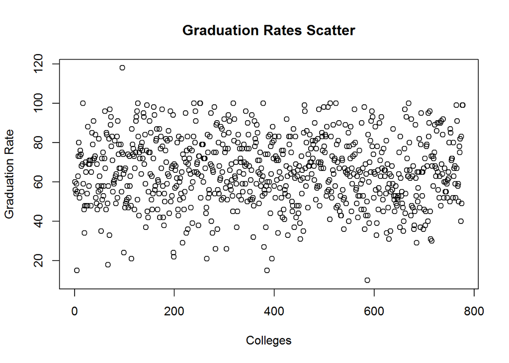

```r
plot(1:777,college$Grad.Rate, xlab='Colleges', ylab='Graduation Rate', main = 'Graduation Rates Scatter')
```

The only interesting aspect of this plot is the set of really low graduation rates for some colleges.

### Histogram

Next, we plot the histogram of the graduation rates, we find that the graduation rates are **seemingly** normally distributed.

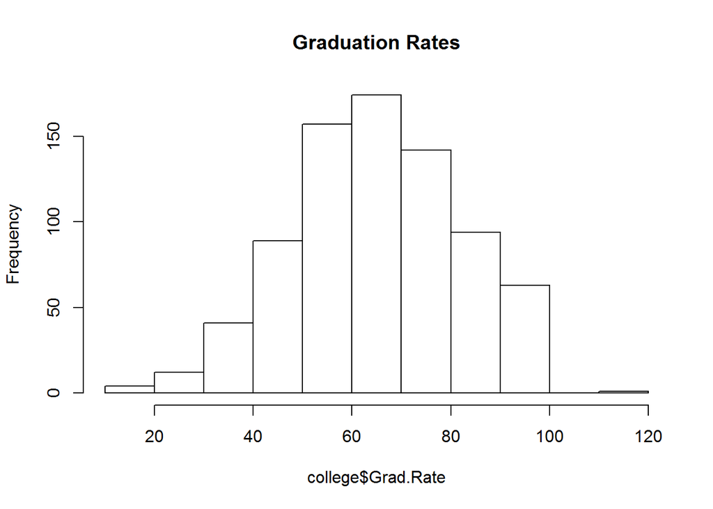

```r
hist(college$Grad.Rate, probability = FALSE, main='Graduation Rates')
```

The y axis provides a count of the colleges with corresponding grad.rate value on the x axis.

We can also plot probabilities instead of count on the y axis as shown below.

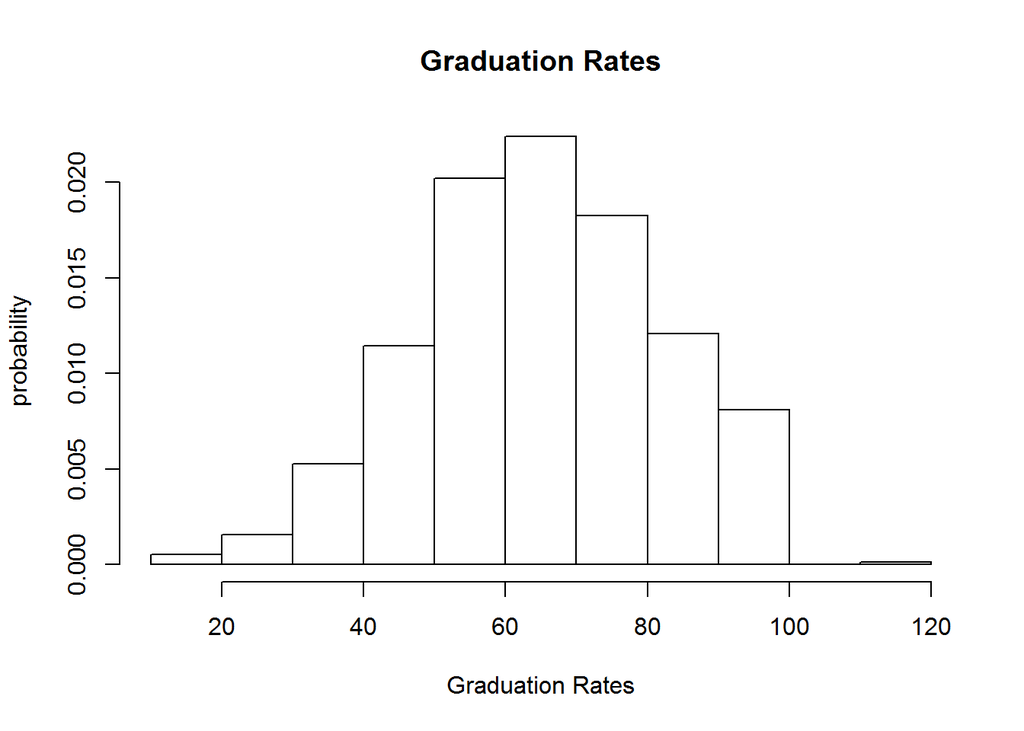

```r
hist(college$Grad.Rate, probability = TRUE, xlab = 'Graduation Rates', ylab = 'probability', main='Graduation Rates')
```

Next, we overlay a normal curve with column mean and standard deviation derived from the summary statistics of graduation rate column.

```r
summary(college$Grad.Rate)
```

```
##    Min. 1st Qu.  Median    Mean 3rd Qu.    Max.
##   10.00   53.00   65.00   65.46   78.00  118.00
```

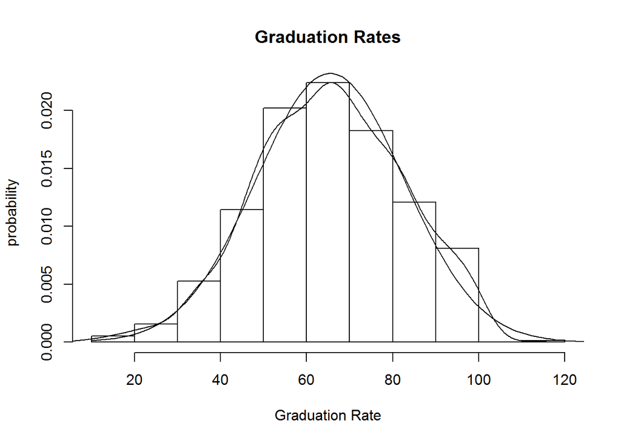

```r
hist(college$Grad.Rate, probability = TRUE, xlab = 'Graduation Rate', ylab = 'probability', main= 'Graduation Rates')
curve(dnorm(x, mean=mean(college$Grad.Rate), sd=sd(college$Grad.Rate)), add=TRUE, colors=c("blue"))
lines (density(college$Grad.Rate), colors=c("red"))
```

The resulting figure shows that normal distribution is a pretty good approximation of the (overlaid) normal curve.

Caution:  
Unlike a normal curve, grad.rates strictly lies between 0 and 100%. The probability calculation using area under curve assume a true normal distribution that is asymptotic in nature. Hence, by bounding the grad.rates, the actual probability will mostly be less than the calculated probability.

## About Normality

The normality of graduation rates, allows us to make inferences about

1. probability of colleges with grad.rate between certain values, i.e., p(a < grad.rate < b), and
2. distribution of differences in grad.rates between Private and Public colleges or other **factor** variables.

## Inference (a) - Cumulative Density Function

R gives us function **pnorm** for computing the probability of grad.rate being less than a specified value. For example, P(60 < X < 70), where X is the grad.rate.

```r
range = c(60,70)
p = pnorm(range, mean=mean(college$Grad.Rate), sd =sd(college$Grad.Rate))
p
```

```
## [1] 0.3752246 0.6041496
```

For better interpretation, we can convert derived probability to count as shown below,

```r
totalCount = sum(college$Grad.Rate)
totalCount
```

```
## [1] 50865
```

```r
count.1 = (p[[1]] * totalCount)/100
count.1
```

```
## [1] 190.858
```

```r
count.2 = (p[[2]] * totalCount)/100
count.2
```

```
## [1] 307.3007
```

```r
  count = count.2 - count.1
  count
```

```
## [1] 116.4427
```

**Interpretation**

p[[1]] - probability of grad.rate being less than 60 p[[2]] - probability of grad.rate being less than 70

We first convert these probabilities to count,where count is the number of college with grad.rate being less than 60 and 7- respectively.

Taking the different, we get the count of colleges between 60 and 709.

Note: We note that, as grad.rate is a continuous variable probability of grade.rate being equal to specific value is typically considered to be zero. In case of continuous random variables, less than, or greater than, or between is more appropriate.

## Correlation of Graduation Rates versus other columns

```r
college.cor = college[,3:19]
cor.df =  cor(college.cor)
```

Correlation (r) of grad.rates with other numeric columns in the first column of data set shown below. The second column shows the r^2. The sign associated with r gives the true direction of the linear relationship and r^2 gives the strength of the relationship.

> It is interesting to note  
> a. grad.rates does not have a strong positive correlation with any of the other variables,  
> b. negative correlation with undergrad columns but a small positive correlation with PhD,  
> c. negative correlation with S.F.Ratio seems to in agreement with above observation as well.

```r
show.cor = cbind(cor.df[1:16, 17], cor.df[1:16, 17]^2, cor.test[1:15,1])
colnames(show.cor) = c("Correlation (r)", "r^2", "p Value")
show.cor
```

```
##             Correlation (r)          r^2      p Value
## Apps            0.146754600 2.153691e-02 4.018556e-05
## Accept          0.067312550 4.530979e-03 6.073426e-02
## Enroll         -0.022341039 4.991220e-04 5.340568e-01
## Top10perc       0.494989235 2.450143e-01 2.897974e-49
## Top25perc       0.477281164 2.277973e-01 1.872333e-45
## F.Undergrad    -0.078773129 6.205206e-03 2.811654e-02
## P.Undergrad    -0.257000991 6.604951e-02 3.468443e-13
## Outstate        0.571289928 3.263722e-01 1.628927e-68
## Room.Board      0.424941541 1.805753e-01 2.046793e-35
## Books           0.001060894 1.125497e-06 9.764463e-01
## Personal       -0.269343964 7.254617e-02 2.216837e-14
## PhD             0.305037850 9.304809e-02 3.399450e-18
## Terminal        0.289527232 8.382602e-02 1.803054e-16
## S.F.Ratio      -0.306710405 9.407127e-02 2.183394e-18
## perc.alumni     0.490897562 2.409804e-01 2.303803e-48
## Expend          0.390342696 1.523674e-01 4.018556e-05
```

Based on a significance level of 0.05 and p values in last column of above table, we can deduce that columns Accept, Enroll and Books will likely not be in a model with Grad.Rate as an independent (y) value.

Lets do a quick regression model between Grad.Rate as independent and remaining variables as dependent variables. As expected the variables, Accept, Enroll, and Books have close to zero coefficients in the resulting regression model. We use this just for validation= purposes.

```r
reg.college = college[,-(1:2),drop=FALSE]
reg.model = lm(Grad.Rate~., data=reg.college)
reg.model
```

```
##
## Call:
## lm(formula = Grad.Rate ~ ., data = reg.college)
##
## Coefficients:
## (Intercept)         Apps       Accept       Enroll    Top10perc
##  37.0418395    0.0011906   -0.0005550    0.0021346    0.0625866
##   Top25perc  F.Undergrad  P.Undergrad     Outstate   Room.Board
##   0.1351558   -0.0005729   -0.0015232    0.0011713    0.0020494
##       Books     Personal          PhD     Terminal    S.F.Ratio
##  -0.0020263   -0.0016712    0.0739653   -0.0887301    0.0261869
## perc.alumni       Expend
##   0.2899368   -0.0004774
```

## Visualizing Correlations

Let us plot grad.rate with an arbitrary selected positively and a negatively correlated column to demonstrate the relationship. Also, just to further contrast the trend, we fit a regression line through the scatter plots.

For regression, it is recommended to normalize the data. So lets first scale the data.

```r
college.scaled = data.frame(scale(college.cor))
```

Next, we fit the regression lines through the 2 scatters.

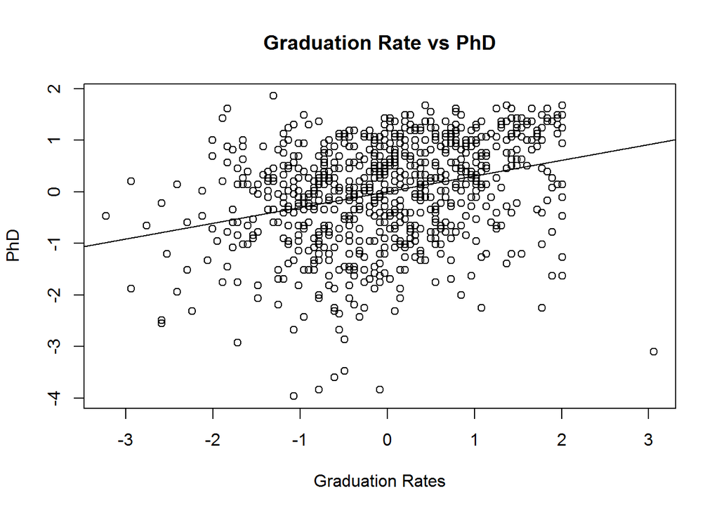

```r
plot(college.scaled$Grad.Rate, college.scaled$PhD, xlab='Graduation Rates', ylab = 'PhD', main = 'Graduation Rate vs PhD')
abline(lm(Grad.Rate~PhD,data=college.scaled))
```

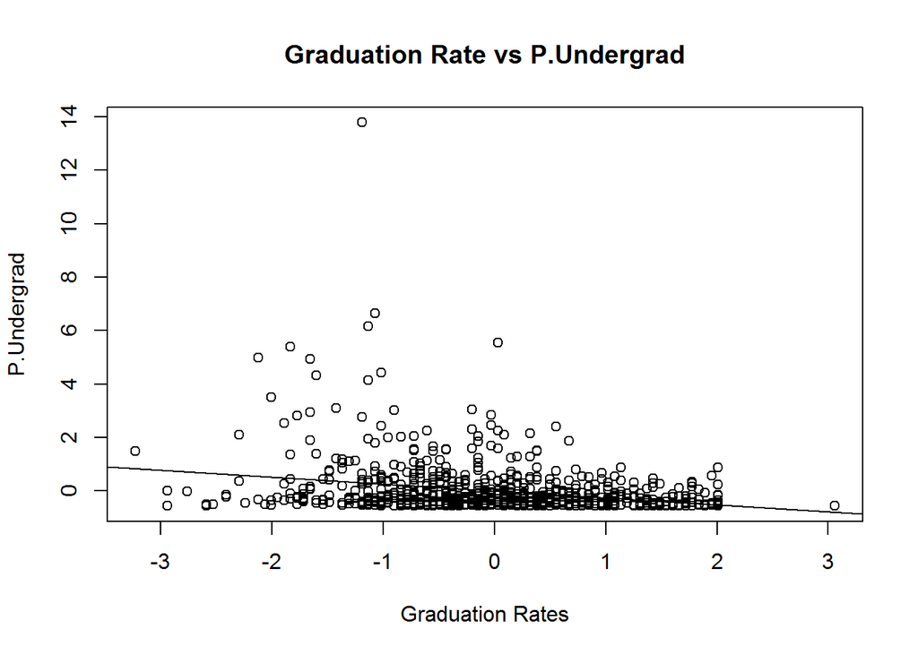

```r
plot(college.scaled$Grad.Rate,college.scaled$P.Undergrad, xlab='Graduation Rates', ylab = 'P.Undergrad', main = 'Graduation Rate vs P.Undergrad')
abline(lm(Grad.Rate~P.Undergrad,data=college.scaled))
```

## Graduation Rates for Private/Public colleges

A box plot of graduation rates segregated by private and public or non-private colleges indicates that  
> a. median graduation rates are higher for Private colleges, b. there are under-performing private schools, c. there are over-performing public schools

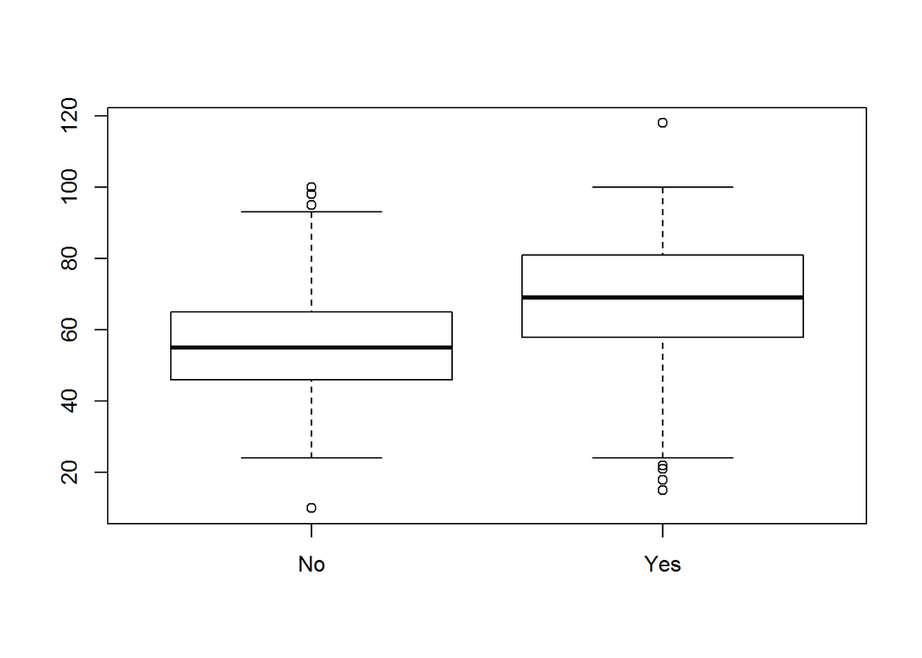

```r
boxplot(Grad.Rate~Private,data=college)
```

## Underperforming Schools

```r
college.private = data.frame(subset(college, college$Private == 'Yes'))
college.public = data.frame(subset(college, college$Private == 'No'))

college.private.u = data.frame(subset(college.private, college.private$Grad.Rate < 25))

college.public.u = data.frame(subset(college, college.public$Grad.Rate < 20))

college.private.u
```

```
##                          Name Private Apps Accept Enroll Top10perc
## 5   Alaska Pacific University     Yes  193    146     55        16
## 67     Brewton-Parker College     Yes 1436   1228   1202        10
## 99          Centenary College     Yes  369    312     90        12
## 114           Claflin College     Yes 1196    697    499        21
## 199            Ferrum College     Yes 1339   1107    336        12
## 265          Huron University     Yes  600    197    124         3
## 385 Montreat-Anderson College     Yes  263    223    103        10
## 395 Mount Saint Clare College     Yes  325    284     95        16
##     Top25perc F.Undergrad P.Undergrad Outstate Room.Board Books Personal
## 5          44         249         869     7560       4120   800     1500
## 67         26        1320         822     4371       2370   500     2000
## 99         46         396         526    11400       5400   500      760
## 114        47         959          13     4412       2460   500     1000
## 199        36        1051          82     9400       4200   500     1600
## 265         9         392          69     7260       3090   600     1840
## 385        24         316          20     8438       3372   500     2958
## 395        33         364          88     9900       3650   500     1200
##     PhD Terminal S.F.Ratio perc.alumni Expend Grad.Rate
## 5    76       72      11.9           2  10922        15
## 67   62       62      12.6          10   4900        18
## 99   41       85       9.5          20   9583        24
## 114  69       69      16.9          31   7083        21
## 199  53       58      12.5           9   7967        22
## 265  31       35      12.9           4   9249        21
## 385  42       50      11.1           4  11989        15
## 395  32       37      13.6          43   6525        21
```

```r
college.public.u
```

[output not shown]